# EP07 - métodos no paramétricos para enfrentar datos numéricos problemáticos

Equipo 5

2025-04-28

# Actividades

En el trabajo de título de una estudiante del DIINF se reportan tiempos de ejecución (en milisegundos) y la cercanía con la solución óptima (en por ciento) de la mejor solución encontrada con tres versiones de un algoritmo genético para resolver instancias del problema del vendedor viajero disponibles en repositorios públicos. Ahora debe enfrentar el análisis de estos datos, por que está solicitando ayuda de las y los estudiantes de Estadística Inferencial.

En el contexto de este estudio, realizaremos las siguientes actividades:

1). Copiar los enunciados de las preguntas asignadas como comentarios de un script R.

2). Obtener los datos, disponibles en el archivo “EP07 Datos.csv”, desde el directorio compartido correspondiente.

3). Familiarizarse con los datos entregados y obtener las muestras indicadas.

4). Enunciar las hipótesis nula y alternativa que permitan responder las preguntas planteadas.

5). Argumentar o escribir código R para verificar que no se cumplen las condiciones para pruebas paramétricas con validez para el caso en estudio.

6). Adaptar las hipótesis a contrastar de acuerdo al método solicitado en cada caso.

7). Escribir código R para realizar los análisis estadísticos para datos problemáticos solicitados.

8). Redactar la respuesta a la pregunta planteada en base a los resultados del análisis realizado.

# Preguntas

1).Observando los datos, la memorista sospecha que hay diferencias significativas en el tiempo de ejecución entre las versiones B y C del algoritmo cuando las instancias tienen 70 o más nodos. ¿Los datos respaldan la intuición de la memorista? Para responder, filtren los datos para tener las instancias con 70 o más nodos y seleccionen las columnas de los tiempos de ejecución de las versiones B y C en formato ancho. Usando como semilla el valor 13, obtenga muestras aleatorias independientes de 20 tiempos registrados por la versión B y 18 tiempos registrados por la versión C del algoritmo. Realicen un análisis estadístico pertinente (enunciar hipótesis, revisar condiciones, seleccionar pruebas ómnibus y post-hoc según corresponda) para responder la pregunta planteada, utilizando pruebas no paramétricas de ser necesario.

R:

Para resolver esta pregunta, primero filtramos las instancias que tienen 70 o más nodos. Luego, mediante una semilla fija (13), seleccionamos muestras independientes de los tiempos de ejecución de las versiones B y C del algoritmo (20 para B y 18 para C).

```r
datos <- read.csv("EP07 Datos.csv")

# Se filtran instancias con 70 o más nodos y seleccionar tiempos B y C (en formato ancho)
datos_filtrados <- datos %>%
  filter(n.nodos >= 70) %>%
  select(tiempo.B, tiempo.C)

# Se fija la semilla y se obtienen muestras aleatorias independientes segun los tamaños indicados
set.seed(13)
muestra_B <- sample(datos_filtrados$tiempo.B, 20)
muestra_C <- sample(datos_filtrados$tiempo.C, 18)

# Crear nuevo dataframe en formato largo para análisis
datos_largo <- data.frame(
  Tiempo = c(muestra_B, muestra_C),
  Version = c(rep("B", length(muestra_B)), rep("C", length(muestra_C)))
)
```

Las hipótesis a contrastar son:

- **Hipótesis nula (H₀): Las distribuciones de los tiempos de ejecución de las versiones B y C son iguales.**
- **Hipótesis alternativa (H₁): Las distribuciones de los tiempos de ejecución de las versiones B y C son distintas.**

Primero se verifica la normalidad de ambas muestras utilizando el test de Shapiro-Wilk y gráficos Q-Q:

```r
# Verificar normalidad (Shapiro-Wilk y gráficos Q-Q)
by(datos_largo$Tiempo, datos_largo$Version, shapiro.test)
```

```
## datos_largo$Version: B
##
##  Shapiro-Wilk normality test
##
## data:  dd[x, ]
## W = 0.87881, p-value = 0.01684
##
## ------------------------------------------------------------
## datos_largo$Version: C
##
##  Shapiro-Wilk normality test
##
## data:  dd[x, ]
## W = 0.96977, p-value = 0.7933
```

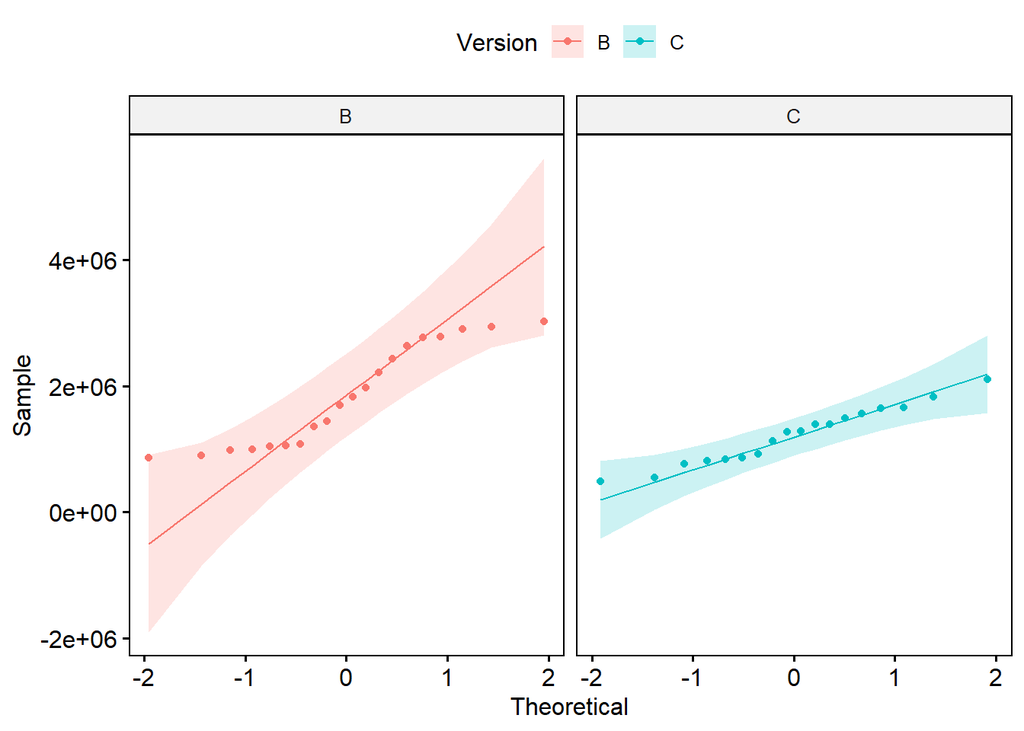

```r
ggqqplot(datos_largo, x = "Tiempo", color = "Version", facet.by = "Version")
```

Se aplicó la prueba de Shapiro-Wilk a cada grupo estudiado, para la versión B se rechaza la normalidad debido a el p-valor = 0.01684 es menor al nivel de significacion 0.05 , y para la versión C: se acepta la normalidad debido al p-valor = 0.7933 es mayor al nivel de significacion 0.05 .

El gráfico Q-Q confirma esta diferencia, mostrando una mayor desviación de la línea teórica en la versión B. Finalmente se tiene que no se cumple el supuesto de normalidad, por lo tanto, no es adecuado aplicar una prueba parametrica.

Por lo cual se ha aplicado la prueba de Wilcoxon-Mann-Whitney, adecuada para comparar dos muestras independientes cuando no se cumple la normalidad. El resultado de esta prueba nos permitirá confirmar o rechazar la intuición de la memorista sobre diferencias en el desempeño entre las versiones B y C.

```r
# Se realiza la prueba no paramétrica (Mann-Whitney-Wilcoxon)
prueba_mannwhitney <- wilcox.test(Tiempo ~ Version, data = datos_largo)

print(prueba_mannwhitney)
```

```
##
##  Wilcoxon rank sum exact test
##
## data:  Tiempo by Version
## W = 262, p-value = 0.01592
## alternative hypothesis: true location shift is not equal to 0
```

Como el p-valor = 0.01592 es menor al nivel de significación 0.05, rechazamos la hipótesis nula en favor de la alternativa. Con un nivel de confianza del 95%, existe evidencia estadística suficiente para afirmar que los tiempos de ejecución de las versiones B y C del algoritmo son significativamente distintos en las instancias con 70 o más nodos, por lo que los datos respaldan la intuicion de la memorista.

2).La memorista también sospecha que, al comparar las mismas instancias de iguales características, las mejores soluciones encontradas por las versiones A y C tienen rendimientos distintos. ¿Estará en lo cierto? Para responder, filtren los datos para tener las instancias con 70 o más nodos y seleccionen las columnas con el mejor rendimiento de las versiones A y C en formato ancho. Usando como semilla el valor 13, obtengan una muestra aleatoria de 24 instancias. Realicen un análisis estadístico pertinente (enunciar hipótesis, revisar condiciones, seleccionar pruebas ómnibus y post-hoc según corresponda) para responder la pregunta planteada, utilizando pruebas no paramétricas de ser necesario.

R:

En esta pregunta, comparamos los rendimientos obtenidos por las versiones A y C del algoritmo sobre las mismas instancias. Por lo tanto, estamos frente a muestras apareadas, ya que cada par de mediciones proviene de la misma instancia. Filtramos las instancias que tienen 70 o más nodos y, usando semilla 13, seleccionamos aleatoriamente 24 instancias para el análisis.

```r
# Se filtran las instancias con 70 o más nodos y se seleccionan rendimientos A y C (formato ancho)
datos_filtrados <- datos %>%
  filter(n.nodos >= 70) %>%
  select(mejor.A, mejor.C)

# Fijar semilla y obtener muestras aleatoria de 24 instancias
set.seed(13)
indices_muestra <- sample(1:nrow(datos_filtrados), 24)

muestra_A <- datos_filtrados$mejor.A[indices_muestra]
muestra_C <- datos_filtrados$mejor.C[indices_muestra]

# Crear nuevo dataframe en formato largo para análisis
datos_largo <- data.frame(
  Mejor = c(muestra_A, muestra_C),
  Version = c(rep("A", length(muestra_A)), rep("C", length(muestra_C))),
  Instancia = rep(1:24, 2) # Importante porque ahora son muestras apareadas
)
```

Las hipótesis a contrastar son:

- **Hipótesis nula (H₀): Las distribuciones de los rendimientos de las versiones A y C son iguales.**
- **Hipótesis alternativa (H₁): Las distribuciones de los rendimientos de las versiones A y C son distintas.**

```r
# Verificamos normalidad (Shapiro-Wilk y gráficos Q-Q)
by(datos_largo$Mejor, datos_largo$Version, shapiro.test)
```

```
## datos_largo$Version: A
##
##  Shapiro-Wilk normality test
##
## data:  dd[x, ]
## W = 0.89298, p-value = 0.01533
##
## ------------------------------------------------------------
## datos_largo$Version: C
##
##  Shapiro-Wilk normality test
##
## data:  dd[x, ]
## W = 0.93633, p-value = 0.1351
```

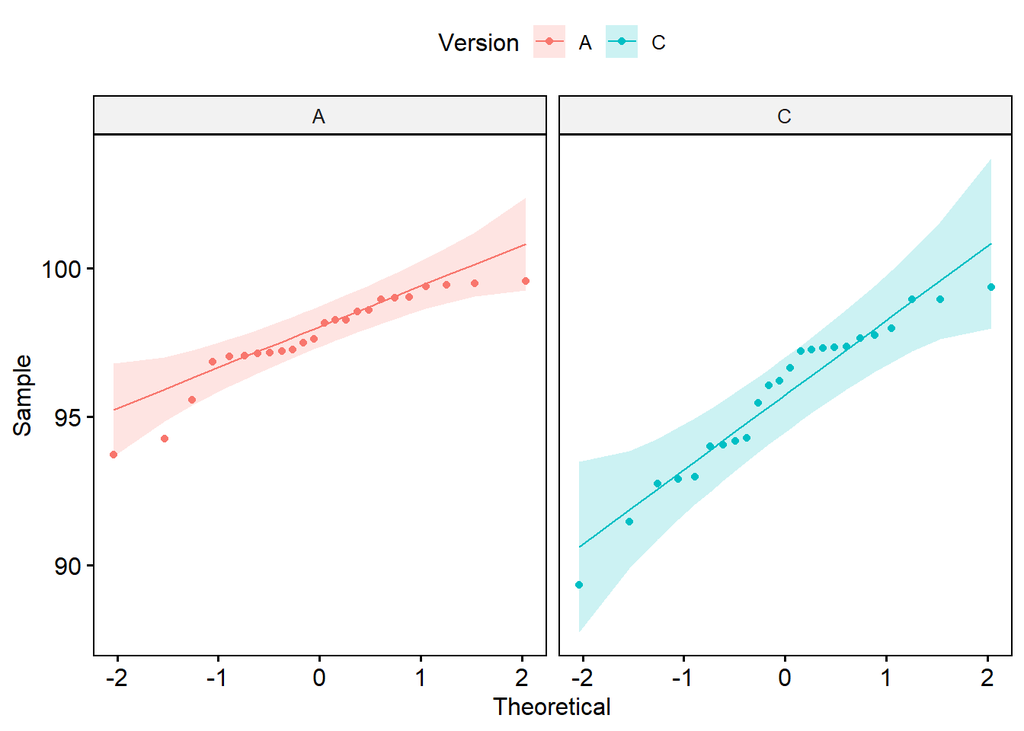

```r
ggqqplot(datos_largo, x = "Mejor", color = "Version", facet.by = "Version")
```

Se aplicó la prueba de Shapiro-Wilk a cada grupo estudiado, para la versión A se rechaza la normalidad debido a el p-valor = 0.01533 es menor al nivel de significacion 0.05 , y para la versión C: se acepta la normalidad debido al p-valor = 0.1351 es mayor al nivel de significacion 0.05 .El gráfico Q-Q confirma esta diferencia, mostrando una mayor desviación de la línea teórica en la versión A.

Al no garantizarse la normalidad de las diferencias entre pares, optamos por un método no paramétrico adecuado para muestras relacionadas: la prueba de rangos con signo de Wilcoxon. Se ha escogido wilcoxon ya que las muestras son apareadas y no se cumple normalidad en una de las muestras.

```r
# Comparación no paramétrica para muestras apareadas
resultado <- wilcox.test(muestra_A, muestra_C, paired = TRUE)
print(resultado)
```

```
##
##  Wilcoxon signed rank test with continuity correction
##
## data:  muestra_A and muestra_C
## V = 253, p-value = 0.0004967
## alternative hypothesis: true location shift is not equal to 0
```

Como el p-valor < 0.05, rechazamos la hipótesis nula en favor de la alternativa. Con un 95% de confianza, podemos afirmar que existen diferencias significativas en el rendimiento entre las versiones A y C del algoritmo. Esto respalda la sospecha de la memorista de que los rendimientos de A y C son distintos.

3).La memorista sospecha que hay diferencias significativas en el tiempo de ejecución entre las versiones del algoritmo cuando las instancias de prueba tienen 50 o más nodos. ¿Los datos respaldan la intuición de la memorista? Para responder, filtren los datos para tener las instancias con 50 o más nodos y seleccionen las columnas con los tiempos de ejecución registrados (en formato ancho). Usando como semilla el valor 54, obtengan muestras aleatorias independientes de 12, 13 y 14 tiempos registrados por las versiones A, B y C, respectivamente. Realicen un análisis estadístico pertinente (enunciar hipótesis, revisar condiciones, seleccionar pruebas ómnibus y post-hoc según corresponda) para responder la pregunta planteada, utilizando pruebas no paramétricas de ser necesario.

R:

Para esta pregunta se busca comparar los tiempos de ejecución de las versiones A, B y C del algoritmo, utilizando instancias con 50 o más nodos. Se tomaron muestras aleatorias independientes usando una semilla de valor 54, con muestras de los siguientes tamaños:

- 12 tiempos para la versión A.
- 13 tiempos para la versión B.
- 14 tiempos para la versión C.

**Código:**

```r
# Filtrar instancias con 50 o más nodos y seleccionar tiempos A, B y C
datos_filtrados <- datos %>%
filter(n.nodos >= 50) %>%
select(tiempo.A, tiempo.B, tiempo.C)

# Fijar semilla y tomar muestras aleatorias independientes de los tamaños indicados
set.seed(54)

muestra_A <- sample(datos_filtrados$tiempo.A, 12)
muestra_B <- sample(datos_filtrados$tiempo.B, 13)
muestra_C <- sample(datos_filtrados$tiempo.C, 14)

# Crear dataframe en formato largo
datos_largo <- data.frame(
  Tiempo = c(muestra_A, muestra_B, muestra_C),
  Version = c(rep("A", 12), rep("B", 13), rep("C", 14))
)
```

Las hipótesis a contrastar son:

- **Hipótesis nula (H₀): Las distribuciones de los tiempos de ejecución de A, B y C son iguales.**
- **Hipótesis alternativa (H₁): Al menos una de las distribucioness difiere.**

```r
# Verificar normalidad por grupo
by(datos_largo$Tiempo, datos_largo$Version, shapiro.test)
```

```
## datos_largo$Version: A
##
##  Shapiro-Wilk normality test
##
## data:  dd[x, ]
## W = 0.88469, p-value = 0.1007
##
## ------------------------------------------------------------
## datos_largo$Version: B
##
##  Shapiro-Wilk normality test
##
## data:  dd[x, ]
## W = 0.93239, p-value = 0.3661
##
## ------------------------------------------------------------
## datos_largo$Version: C
##
##  Shapiro-Wilk normality test
##
## data:  dd[x, ]
## W = 0.84363, p-value = 0.01822
```

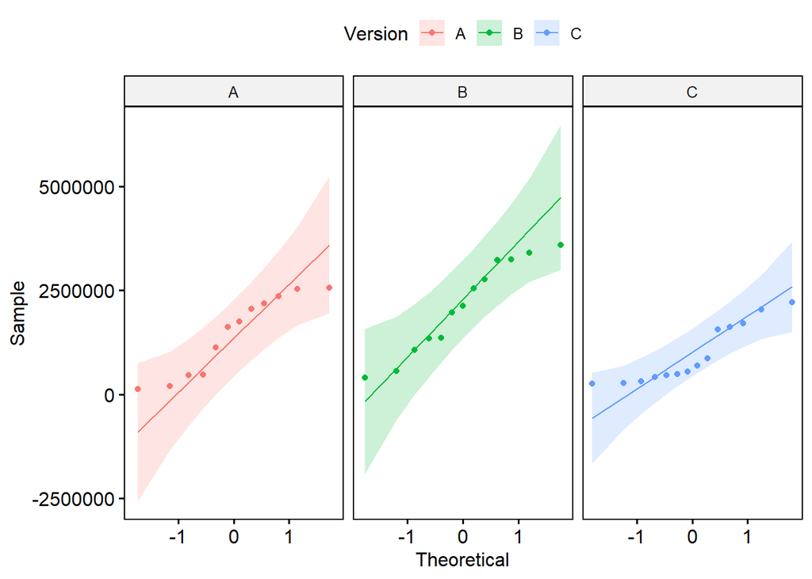

```r
# Graficar Q-Q plots por grupo
ggqqplot(datos_largo, x = "Tiempo", facet.by = "Version", color = "Version")
```

```r
# Verificar homogeneidad de varianzas
leveneTest(Tiempo ~ Version, data = datos_largo)
```

```
## Levene's Test for Homogeneity of Variance (center = median)
##       Df F value Pr(>F)
## group  2   1.637 0.2087
##       36
```

Luego de verificar la normalidad mediante Shapiro-Wilk y los gráficos Q-Q, obteniendo que para versiones A y B no se rechaza la normalidad dado que sus p-valores son mayores al nivel de significacion 0.05, pero para el valor C se obtuvo un p-valor de 0.01822, menor al nivel de significancia, indicando no normalidad en esta muestra.

Al evaluar la homogeneidad de varianzas con el test de Levene, este entrega p-valor 0.2087 (mayor a 0.05), por lo tanto, no se rechaza la hipótesis (de levene) de igualdad de varianzas, en otras palabras si se presenta homogeneidad de varianzas.

Ademas, las muestras son de tamaños diferentes, por lo tanto no se puede usar una prueba parametrica como ANOVA,y si la muestra hubiera sido de nivel 2 (es de nivel 3), seria mas recomendable utilizar la prueba Wilcoxon-Mann-Whitney. Por lo tanto se evidencia que no se cumplen todas las condiciones para aplicar ANOVA. Por tanto, se recurre al procedimiento no paramétrico de Kruskal-Wallis, la cual permite contrastar las hipótesis bajo un enfoque robusto ante problemas de normalidad o varianza desigual.

```r
# Aplicamos prueba de Kruskal-Wallis
prueba_kw <- kruskal.test(Tiempo ~ Version, data = datos_largo)
print(prueba_kw)
```

```
##
##  Kruskal-Wallis rank sum test
##
## data:  Tiempo by Version
## Kruskal-Wallis chi-squared = 7.5986, df = 2, p-value = 0.02239
```

Se obtuvo un p-valor = 0.02239 (menor a 0.05), por lo que existe suficiente evidencia estadística al 5% de significancia para concluir que al menos una de las versiones (A, B o C) tiene un tiempo de ejecución distinto en las instancias con 50 o más nodos. Por tanto, los datos sí respaldan la intuición de la memorista: las versiones tienen rendimientos significativamente diferentes en tiempos de ejecución.

La prueba de Kruskal-Wallis sólo indica que existen diferencias, pero no especifica entre qué versiones están esas diferencias (A vs B, A vs C o B vs C). Se debe realizar un análisis post-hoc usando comparaciones por pares, como el Wilcoxon-Mann-Whitney con corrección de múltiples comparaciones (por ejemplo, método Benjamini-Hochberg).

```r
# Comparaciones post-hoc usando Wilcoxon para todas las combinaciones
post_hoc_resultado <- pairwise.wilcox.test(
  datos_largo$Tiempo,          # variable de interés
  datos_largo$Version,         # variable de agrupaciónx
  p.adjust.method = "BH"       # corrección Benjamini-Hochberg para controlar el error
)

print(post_hoc_resultado)
```

```
##
##  Pairwise comparisons using Wilcoxon rank sum exact test
##
## data:  datos_largo$Tiempo and datos_largo$Version
##
##   A    B
## B 0.20 -
## C 0.21 0.02
##
## P value adjustment method: BH
```

- Solo la comparación entre versiones B y C muestra una diferencia significativa (p-valor = 0.02 < 0.05).
- No se observan diferencias significativas entre A y B ni entre A y C.( p-valor(A vs B)= 0.20 > 0.05 Y p-valor(A vs C)= 0.21 > 0.05 ).

Entonces, como el p-valor obtenido en la prueba de Kruskal-Wallis (p-valor = 0.02239) es menor al nivel de significancia del 5%, rechazamos la hipótesis nula en favor de la alternativa. Con un 95% de nivel de confianza, existe evidencia estadística suficiente para afirmar que los tiempos de ejecución de al menos una de las versiones del algoritmo difiere significativamente respecto a las otras, en las instancias con 50 o más nodos. El análisis post-hoc indicó que esta diferencia significativa ocurre específicamente entre las versiones B y C. Por lo tanto, los datos respaldan parcialmente la intuición de la memorista, ya que no todas las versiones difieren entre sí, pero sí se observa una diferencia estadísticamente significativa entre dos de ellas.

4).La memorista también sospecha que, al comparar las mismas instancias con iguales características, las mejores soluciones encontradas por las diferentes versiones del algoritmo tienen rendimientos distintos. ¿Estará en lo cierto? Para responder, filtren los datos para tener las instancias con 50 o más nodos y seleccionen las columnas con los mejores rendimientos registrados. Usando como semilla el valor 54, obtengan una muestra aleatoria de 22 instancias. Realicen un análisis estadístico pertinente (enunciar hipótesis, revisar condiciones, seleccionar pruebas ómnibus y post-hoc según corresponda) para responder la pregunta planteada, utilizando pruebas no paramétricas de ser necesario.

R:

Ahora se busca comparar los mejores rendimientos de las versiones A, B y C del algoritmo para instancias con 50 o más nodos. Se tomó una muestra aleatoria de 22 instancias, respetando la semilla 54.

**Código:**

```r
# Filtrar instancias con 50 o más nodos y seleccionar mejores rendimientos
datos_filtrados <- datos %>%
  filter(n.nodos >= 50) %>%
  select(mejor.A, mejor.B, mejor.C)

# Fijar semilla y tomar una muestra aleatoria de 22 instancias
set.seed(54)

indices_muestra <- sample(1:nrow(datos_filtrados), 22)
muestra <- datos_filtrados[indices_muestra, ]

# Transformar datos a formato largo
datos_largo <- data.frame(
  Rendimiento = c(muestra$mejor.A, muestra$mejor.B, muestra$mejor.C),
  Version = c(rep("A", 22), rep("B", 22), rep("C", 22)),
  Instancia = rep(1:22, 3)
)
```

Debido a que las mediciones de rendimiento se obtienen en las mismas instancias bajo distintas versiones, demuestra que los datos son dependientes (muestras relacionadas). Por eso, para verificar la normalidad, se analizan las diferencias por pares usando Shapiro-Wilk y gráficos Q-Q.

```r
# Verificar normalidad de las diferencias y crear matriz de diferencias

datos_ancho <- pivot_wider(datos_largo, names_from = Version, values_from = Rendimiento)

# Cálculo de diferencias por pares
diferencias_AB <- datos_ancho$A - datos_ancho$B
diferencias_AC <- datos_ancho$A - datos_ancho$C
diferencias_BC <- datos_ancho$B - datos_ancho$C

# Evaluar normalidad de las diferencias
shapiro.test(diferencias_AB)
```

```
##
##  Shapiro-Wilk normality test
##
## data:  diferencias_AB
## W = 0.92313, p-value = 0.08829
```

```r
shapiro.test(diferencias_AC)
```

```
##
##  Shapiro-Wilk normality test
##
## data:  diferencias_AC
## W = 0.96657, p-value = 0.632
```

```r
shapiro.test(diferencias_BC)
```

```
##
##  Shapiro-Wilk normality test
##
## data:  diferencias_BC
## W = 0.97462, p-value = 0.8148
```

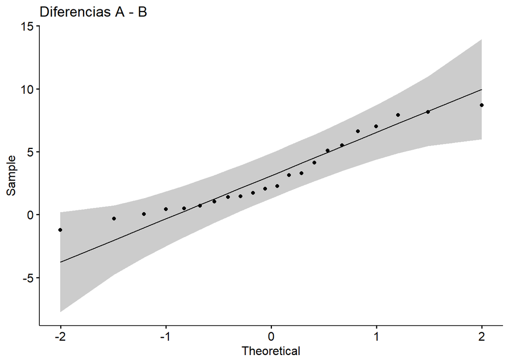

```r
# Gráfico Q-Q para diferencias
ggqqplot(data.frame(diff = diferencias_AB), x = "diff") + ggtitle("Diferencias A - B")
```

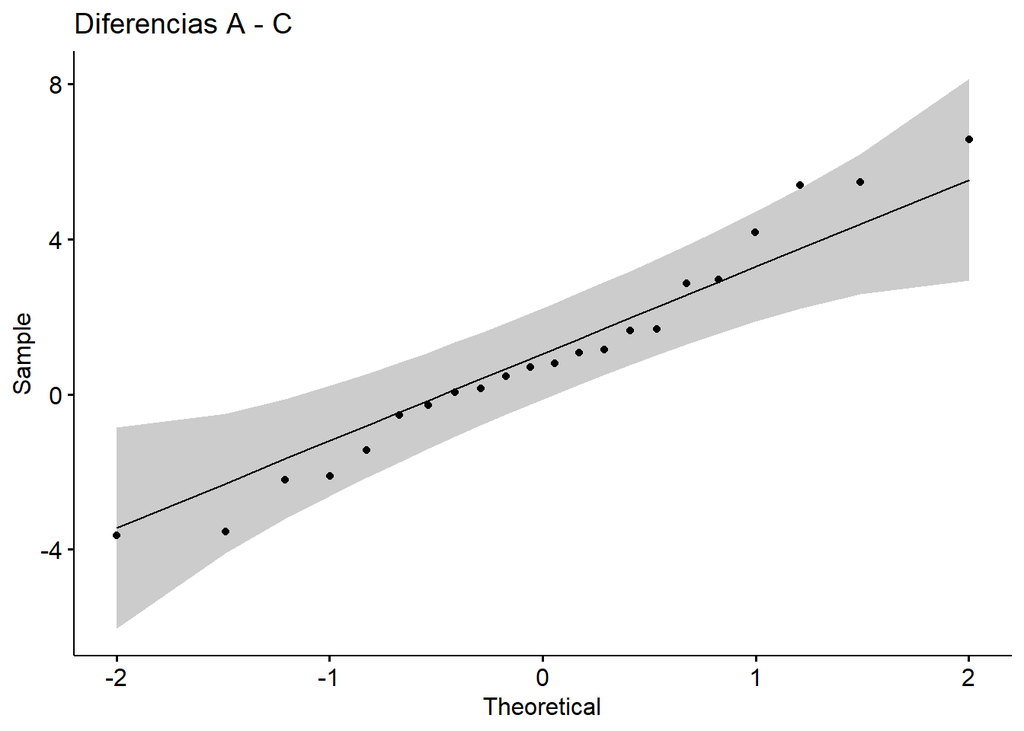

```r
ggqqplot(data.frame(diff = diferencias_AC), x = "diff") + ggtitle("Diferencias A - C")
```

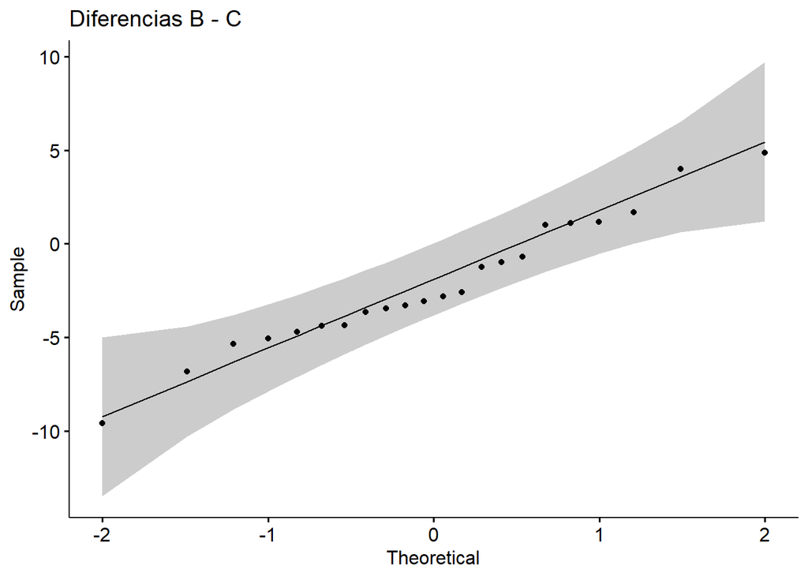

```r
ggqqplot(data.frame(diff = diferencias_BC), x = "diff") + ggtitle("Diferencias B - C")
```

Las hipótesis a contrastar son:

- **Hipótesis nula (H₀): Las distribuciones de rendimientos son iguales entre A, B y C.**
- **Hipótesis alternativa (H₁): Al menos una versión del algoritmo posee una distribución de rendimiento distinta que al menos otra versión del algoritmo.**

```r
# Dado que no se cumple normalidad, aplicamos prueba de Friedman
prueba_friedman <- friedman.test(Rendimiento ~ Version | Instancia, data = datos_largo)
print(prueba_friedman)
```

```
##
##  Friedman rank sum test
##
## data:  Rendimiento and Version and Instancia
## Friedman chi-squared = 16.636, df = 2, p-value = 0.000244
```

El resultado obtenido en la prueba de Friedman muestra un p-valor de 0.000244, que es mucho menor que el nivel de significancia. Esto nos lleva a rechazar la hipótesis nula, concluyendo que existen diferencias significativas en el rendimiento logrado por las distintas versiones del algoritmo. En consecuencia, podemos afirmar que no todos los rendimientos de las versiones A, B y C son iguales.

Por supuesto esta conclusión es de tipo ómnibus y es necesario realizar un procedimiento post-hoc para identificar entre qué versiones (A vs B, A vs C, B vs C) se encuentran esas diferencias específicas. En este caso usaremos Wilcoxon utilizando la correción de Holm.

```r
# Comparaciones post-hoc usando Wilcoxon para muestras apareadas
post_hoc_resultado <- pairwise.wilcox.test(datos_largo$Rendimiento,
                                           datos_largo$Version,
                                           paired = TRUE,          # porque es comparación en instancias iguales.
                                           p.adjust.method = "holm" # corrección de Holm para controlar error.
                                           )
print(post_hoc_resultado)
```

```
##
##  Pairwise comparisons using Wilcoxon signed rank exact test
##
## data:  datos_largo$Rendimiento and datos_largo$Version
##
##   A       B
## B 4.7e-05 -
## C 0.137   0.025
##
## P value adjustment method: holm
```

El análisis post-hoc usando la prueba de Wilcoxon para muestras apareadas (con corrección de Holm) entrega los siguientes resultados:

- La versión A y la versión B tienen rendimientos significativamente diferentes. (A vs B: p-valor = 4.7e-05)
- La versión B y la versión C también presentan diferencias significativas. (B vs C: p-valor = 0.025)
- La versión A y la versión C no muestran diferencias estadísticamente significativas. (A vs C: p-valor = 0.137)

Esto sugiere que la versión B se comporta de manera distinta en su rendimiento en comparación con las versiones A y C, mientras que las versiones A y C son similares entre sí respecto al mejor rendimiento obtenido.

Entonces, como el p-valor es menor al nivel de significancia, rechazamos la hipótesis nula, con un 95% de nivel de confianza, existe evidencia estadística suficiente como para afirmar que las mejores soluciones encontradas por las diferentes versiones del algoritmo tienen rendimientos distintos, más específico, las versiones del algoritmo A y B al igual que B y C que son significativamente distintos en las 22 instancias con 50 o más nodos. Por lo que los datos respaldan la intuicion de la memorista.